# Pendugaan Parameter, Diagnostik Model, dan Peramalan

Nabil Naufal (G1401211008)

## Packages yang digunakakan

```r
library(ggplot2)
library(tsibble)
library(tseries)
library(MASS)
library(forecast)
library(TSA)
library(TTR)
library(aTSA)
library(graphics)
```

## Penyiapan Data

```r
#Input data
datadeath<-rio::import("https://raw.githubusercontent.com/mrnabilnaufal07/mpdw/main/Data/Data-Nabil.csv")

#Menghapus data periode
datadeath <- datadeath$Meninggal

#Mengubah tipe data menjadi time series
datadeath.ts<-ts(datadeath)
```

## Eksplorasi Data

### Plot Data Penuh

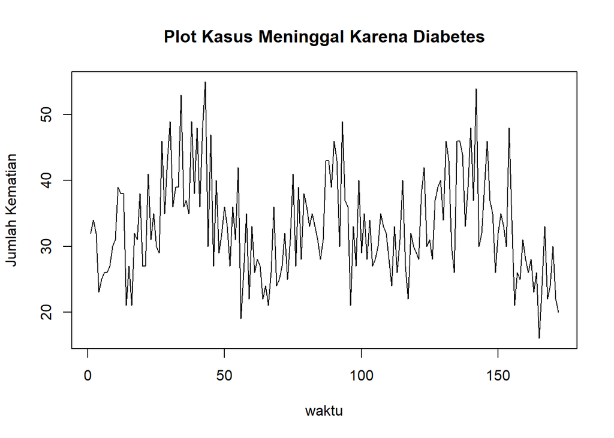

```r
plot.ts(datadeath.ts, xlab="waktu", ylab="Jumlah Kematian", main="Plot Kasus Meninggal Karena Diabetes")
```

Berdasarkan plot data deret waktu, terlihat bahwa data memiliki pola siklik. Berdasarkan pola data, pembagian data latih dan data uji ditetapkan dengan proporsi 70%:30%.

### Plot Data Latih

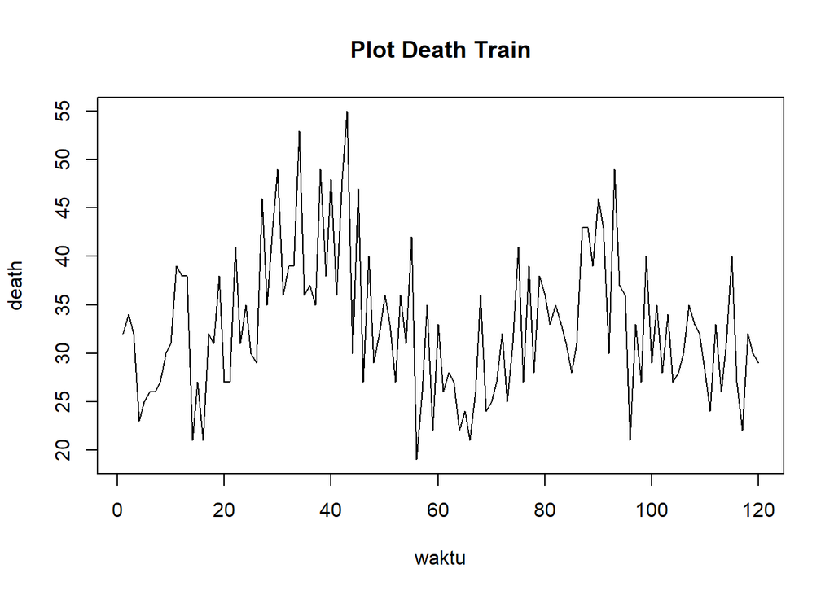

```r
deathtrain<-datadeath[1:120]
train.ts<-ts(deathtrain)
plot.ts(train.ts, lty=1, xlab="waktu", ylab="death", main="Plot Death Train")
```

Berdasarkan plot data deret waktu pada data latih, terlihat bahwa data cenderung memiliki trend yang naik dan turun. Hal ini mengindikasikan bahwa data tidak stasioner dalam rataan.

### Plot Data Uji

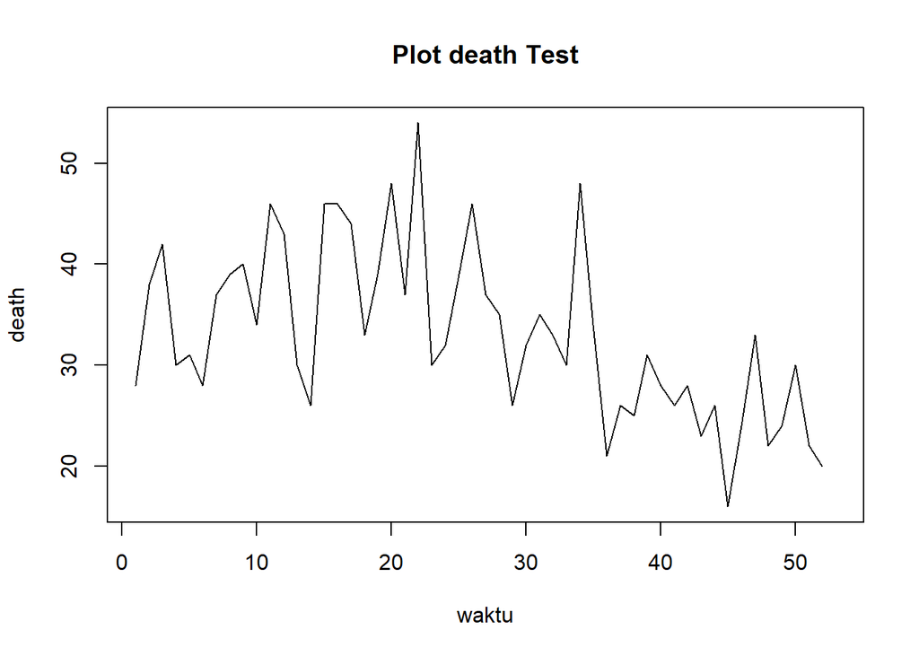

```r
deathtest<-datadeath[121:173]
test.ts<-ts(deathtest)
plot.ts(test.ts, lty=1, xlab="waktu", ylab="death", main="Plot death Test")
```

## Uji Stasioneritas Data

### Plot ACF

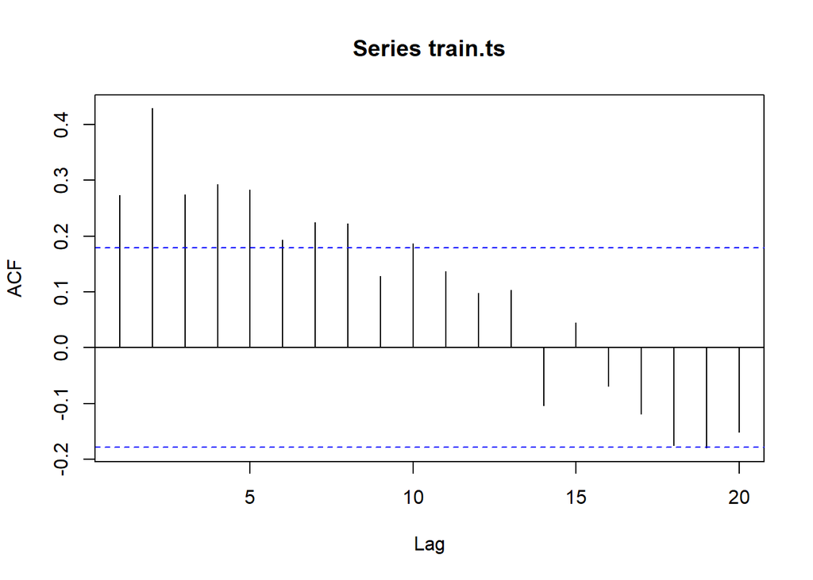

```r
acf(train.ts)
```

Berdasarkan plot ACF, terlihat bahwa plot ACF data menurun secara perlahan (*tails of slowly*). Hal ini juga menjadi indikasi bahwa data tidak stasioner dalam rataan

### Uji ADF

```r
tseries::adf.test(train.ts)
```

```
##
##  Augmented Dickey-Fuller Test
##
## data:  train.ts
## Dickey-Fuller = -2.6413, Lag order = 4, p-value = 0.3102
## alternative hypothesis: stationary
```

$H_0$ : Data tidak stasioner dalam rataan

$H_1$ : Data stasioner dalam rataan

Berdasarkan uji ADF tersebut, didapat *p-value* sebesar 0.3102 yang lebih besar dari taraf nyata 5% sehingga tak tolak $H_0$ dan menandakan bahwa data tidak stasioner dalam rataan. Hal ini sesuai dengan hasil eksplorasi menggunakan plot time series dan plot ACF, sehingga ketidakstasioneran model kedepannya harus ditangani

### Plot Box-Cox

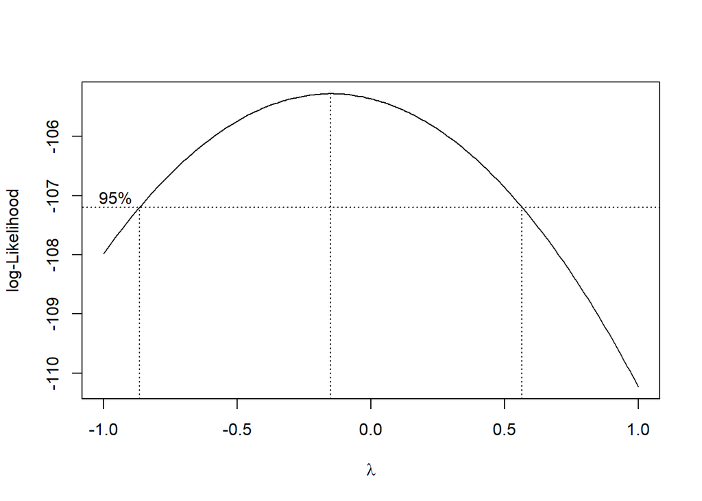

```r
index <- seq(1:120)
bc = boxcox(train.ts~index, lambda = seq(-1,1,by=0.01))
```

```r
#Nilai Rounded Lambda
lambda <- bc$x[which.max(bc$y)]
lambda
```

```
## [1] -0.15
```

```r
#SK
bc$x[bc$y > max(bc$y) - 1/2 * qchisq(.95,1)]
```

```
##   [1] -0.86 -0.85 -0.84 -0.83 -0.82 -0.81 -0.80 -0.79 -0.78 -0.77 -0.76 -0.75
##  [13] -0.74 -0.73 -0.72 -0.71 -0.70 -0.69 -0.68 -0.67 -0.66 -0.65 -0.64 -0.63
##  [25] -0.62 -0.61 -0.60 -0.59 -0.58 -0.57 -0.56 -0.55 -0.54 -0.53 -0.52 -0.51
##  [37] -0.50 -0.49 -0.48 -0.47 -0.46 -0.45 -0.44 -0.43 -0.42 -0.41 -0.40 -0.39
##  [49] -0.38 -0.37 -0.36 -0.35 -0.34 -0.33 -0.32 -0.31 -0.30 -0.29 -0.28 -0.27
##  [61] -0.26 -0.25 -0.24 -0.23 -0.22 -0.21 -0.20 -0.19 -0.18 -0.17 -0.16 -0.15
##  [73] -0.14 -0.13 -0.12 -0.11 -0.10 -0.09 -0.08 -0.07 -0.06 -0.05 -0.04 -0.03
##  [85] -0.02 -0.01  0.00  0.01  0.02  0.03  0.04  0.05  0.06  0.07  0.08  0.09
##  [97]  0.10  0.11  0.12  0.13  0.14  0.15  0.16  0.17  0.18  0.19  0.20  0.21
## [109]  0.22  0.23  0.24  0.25  0.26  0.27  0.28  0.29  0.30  0.31  0.32  0.33
## [121]  0.34  0.35  0.36  0.37  0.38  0.39  0.40  0.41  0.42  0.43  0.44  0.45
## [133]  0.46  0.47  0.48  0.49  0.50  0.51  0.52  0.53  0.54  0.55  0.56
```

Plot Boxcox menunjukkan nilai *rounded value* ($\lambda$) optimum sebesar **-0.15** dan pada selang kepercayaan 95% nilai memiliki batas bawah **-0.86** dan batas atas **0.56**. Selang tersebut tidak memuat nilai satu sehingga dapat dikatakan bahwa data yang digunakan tidak stasioner dalam ragam.

## Penanganan Ketidakstasioneran Data

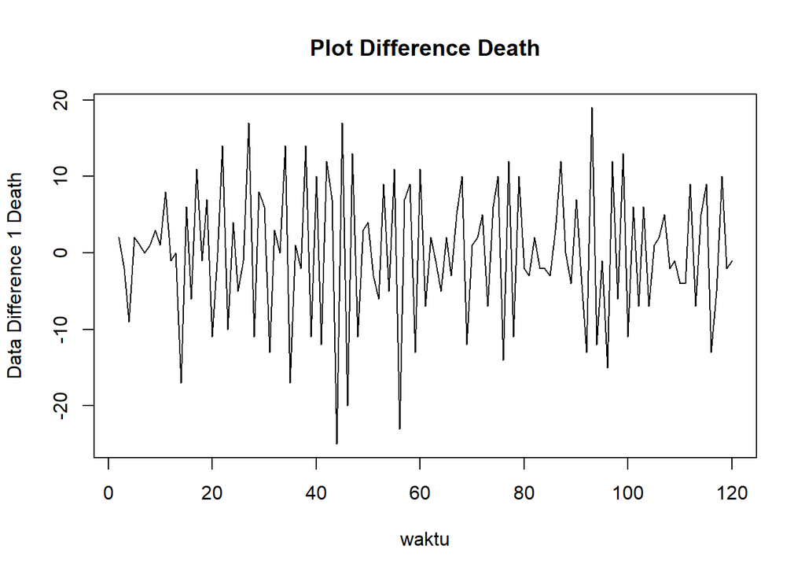

```r
train.diff<-diff(train.ts,differences = 1)
plot.ts(train.diff, lty=1, xlab="waktu", ylab="Data Difference 1 Death", main="Plot Difference Death")
```

Berdasarkan plot data deret waktu, terlihat bahwa data sudah stasioner dalam rataan ditandai dengan data bergerak pada nilai tengah tertentu (tidak terdapat trend ataupun musiman pada data)

### Plot ACF

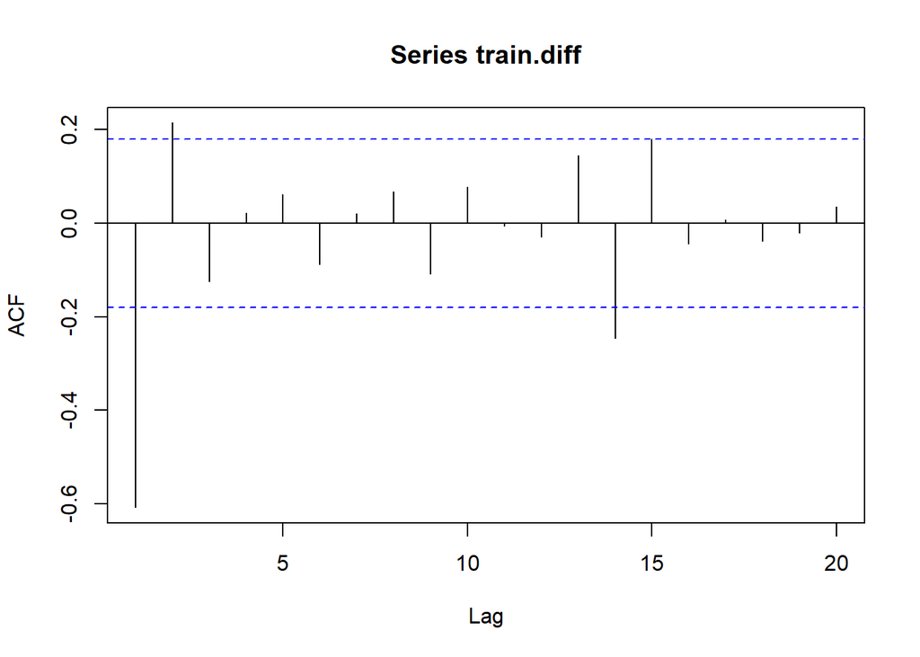

```r
acf(train.diff)
```

Berdasarkan plot tersebut, terlihat bahwa plot ACF cuts off pada lag ke 1. Hal ini menandakan data sudah stasioner dalam rataan dan ketidakstasioneran data telah berhasil tertangani.

### Uji ADF

```r
tseries::adf.test(train.diff)
```

```
##
##  Augmented Dickey-Fuller Test
##
## data:  train.diff
## Dickey-Fuller = -6.9241, Lag order = 4, p-value = 0.01
## alternative hypothesis: stationary
```

$H_0$ : Data tidak stasioner dalam rataan

$H_1$ : Data stasioner dalam rataan

Berdasarkan uji ADF tersebut, didapat *p-value* sebesar 0.01 yang lebih kecil dari taraf nyata 5% sehingga tolak $H_0$ atau data stasioner dalam rataan. Hal ini sesuai dengan hasil eksplorasi menggunakan plot time series dan plot ACF, sehingga dalam hal ini ketidakstasioneran data sudah berhasil ditangani dan dapat dilanjutkan ke pemodelan

## Identifikasi Model

### Plot ACF

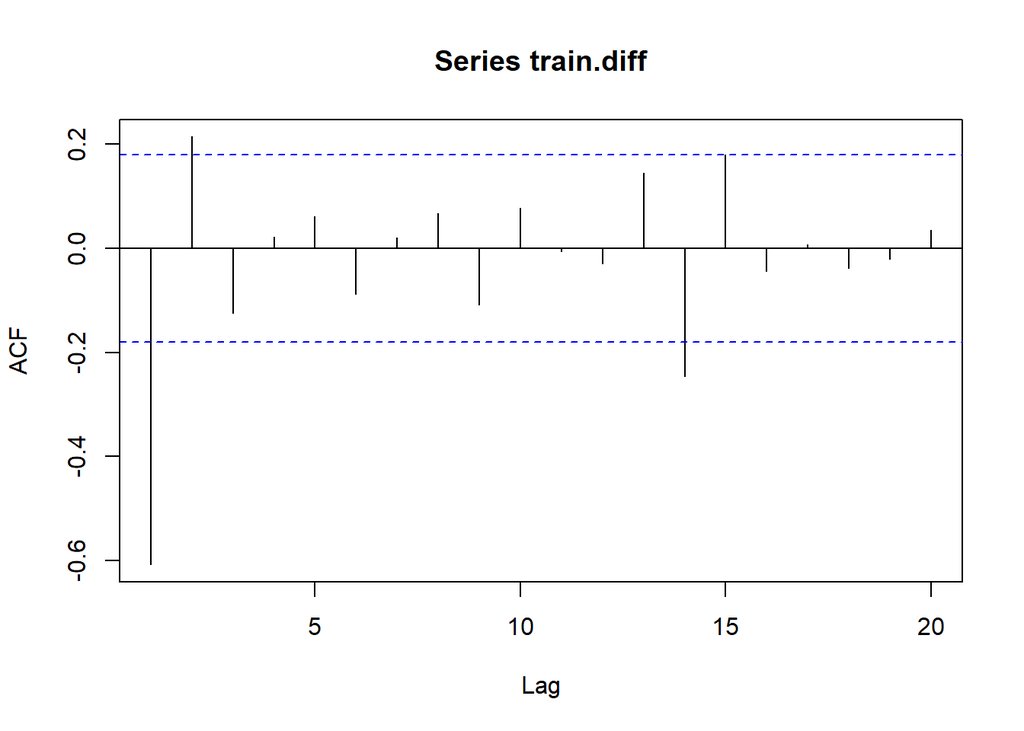

```r
acf(train.diff)
```

Berdasarkan plot tersebut, terlihat bahwa plot ACF cenderung *cuts off* pada lag ke 1, sehingga jika plot PACF dianggap *tails of*, maka model tentatifnya adalah ARIMA(0,1,1).

### Plot PACF

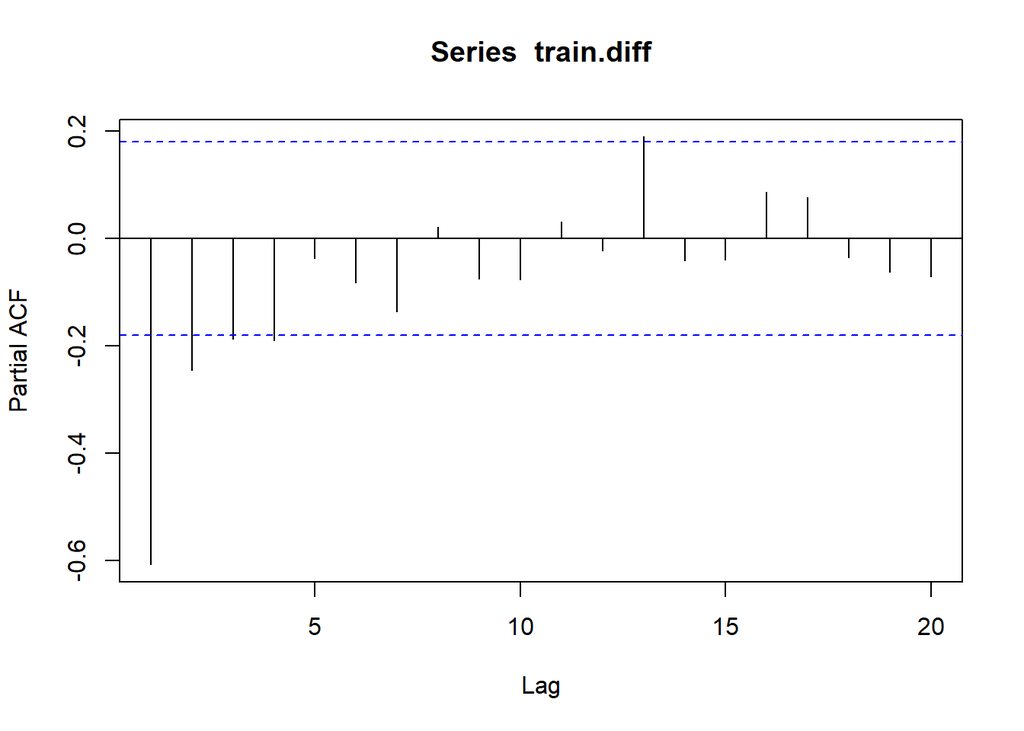

```r
pacf(train.diff)
```

Berdasarkan plot tersebut, terlihat bahwa plot PACF cenderung *cuts off* pada lag ke 2, sehingga jika plot ACF dianggap *tails of*, maka model tentatifnya adalah ARIMA(2,1,0).

Jika baik plot ACF maupun plot PACF keduanya dianggap tails of, maka model yang terbentuk adalah ARIMA(1,1,1)

### Plot EACF

```r
eacf(train.diff)
```

```
## AR/MA
##   0 1 2 3 4 5 6 7 8 9 10 11 12 13
## 0 x x o o o o o o o o o  o  o  x
## 1 x x o o o o o o o o o  o  o  x
## 2 x o x o o o o o o o o  o  o  o
## 3 x o x o o o o o o o o  o  o  o
## 4 x x x o o o o o o o o  o  o  o
## 5 x o x x o o o o o o o  o  o  o
## 6 x o x o o o o o o o o  o  o  o
## 7 o x x o o o o o o o o  o  o  o
```

Identifikasi model menggunakan plot EACF dilakukan dengan melihat ujung segitiga pada pola segitiga nol. Dalam hal ini model tentatif yang terbentuk adalah ARIMA(0,1,2), ARIMA(1,1,2), dan ARIMA(2,1,1)

## Pendugaan Parameter Model Tentatif

### ARIMA(0,1,1)

```r
model1.da=Arima(train.diff, order=c(0,1,1),method="ML")
summary(model1.da) #AIC=861.26
```

```
## Series: train.diff
## ARIMA(0,1,1)
##
## Coefficients:
##          ma1
##       -1.000
## s.e.   0.021
##
## sigma^2 = 81.05:  log likelihood = -428.63
## AIC=861.26   AICc=861.37   BIC=866.8
##
## Training set error measures:
##                       ME     RMSE      MAE MPE MAPE      MASE       ACF1
## Training set -0.02097883 8.926839 7.156795 NaN  Inf 0.5530464 -0.6061335
```

```r
lmtest::coeftest(model1.da) #seluruh parameter signifikan
```

```
##
## z test of coefficients:
##
##      Estimate Std. Error z value  Pr(>|z|)
## ma1 -1.000000   0.021007 -47.602 < 2.2e-16 ***
## ---
## Signif. codes:  0 '***' 0.001 '**' 0.01 '*' 0.05 '.' 0.1 ' ' 1
```

### ARIMA(2,1,0)

```r
model2.da=Arima(train.diff, order=c(2,1,0),method="ML")
summary(model2.da) #AIC=864.86
```

```
## Series: train.diff
## ARIMA(2,1,0)
##
## Coefficients:
##           ar1      ar2
##       -1.1229  -0.4893
## s.e.   0.0799   0.0797
##
## sigma^2 = 85.28:  log likelihood = -429.43
## AIC=864.86   AICc=865.07   BIC=873.18
##
## Training set error measures:
##                       ME     RMSE      MAE MPE MAPE      MASE       ACF1
## Training set 0.007483314 9.117691 6.984824 NaN  Inf 0.5397572 -0.1757061
```

```r
lmtest::coeftest(model2.da) #seluruh parameter signifikan
```

```
##
## z test of coefficients:
##
##      Estimate Std. Error  z value  Pr(>|z|)
## ar1 -1.122912   0.079927 -14.0492 < 2.2e-16 ***
## ar2 -0.489348   0.079750  -6.1361  8.46e-10 ***
## ---
## Signif. codes:  0 '***' 0.001 '**' 0.01 '*' 0.05 '.' 0.1 ' ' 1
```

### ARIMA(1,1,1)

```r
model3.da=Arima(train.diff, order=c(1,1,1),method="ML")
summary(model3.da) #AIC=810.27
```

```
## Series: train.diff
## ARIMA(1,1,1)
##
## Coefficients:
##           ar1      ma1
##       -0.5995  -1.0000
## s.e.   0.0726   0.0219
##
## sigma^2 = 51.57:  log likelihood = -402.13
## AIC=810.27   AICc=810.48   BIC=818.58
##
## Training set error measures:
##                      ME     RMSE      MAE MPE MAPE      MASE       ACF1
## Training set 0.03990198 7.089887 5.486836 NaN  Inf 0.4239991 -0.1514496
```

```r
lmtest::coeftest(model3.da) #seluruh parameter signifikan
```

```
##
## z test of coefficients:
##
##      Estimate Std. Error  z value  Pr(>|z|)
## ar1 -0.599516   0.072619  -8.2556 < 2.2e-16 ***
## ma1 -0.999999   0.021878 -45.7086 < 2.2e-16 ***
## ---
## Signif. codes:  0 '***' 0.001 '**' 0.01 '*' 0.05 '.' 0.1 ' ' 1
```

### ARIMA(0,1,2)

```r
model4.da=Arima(train.diff, order=c(0,1,2),method="ML")
summary(model4.da) #AIC=799.27
```

```
## Series: train.diff
## ARIMA(0,1,2)
##
## Coefficients:
##           ma1     ma2
##       -1.7523  0.7523
## s.e.   0.0661  0.0620
##
## sigma^2 = 46.11:  log likelihood = -396.64
## AIC=799.27   AICc=799.48   BIC=807.59
##
## Training set error measures:
##                      ME     RMSE      MAE MPE MAPE      MASE       ACF1
## Training set -0.2056647 6.704611 5.374915 NaN  Inf 0.4153504 -0.1336757
```

```r
lmtest::coeftest(model4.da) #seluruh parameter signifikan
```

```
##
## z test of coefficients:
##
##      Estimate Std. Error z value  Pr(>|z|)
## ma1 -1.752257   0.066142 -26.492 < 2.2e-16 ***
## ma2  0.752266   0.061965  12.140 < 2.2e-16 ***
## ---
## Signif. codes:  0 '***' 0.001 '**' 0.01 '*' 0.05 '.' 0.1 ' ' 1
```

### ARIMA(1,1,2)

```r
model5.da=Arima(train.diff, order=c(1,1,2),method="ML")
summary(model5.da) #AIC=798.02
```

```
## Series: train.diff
## ARIMA(1,1,2)
##
## Coefficients:
##           ar1      ma1     ma2
##       -0.2213  -1.6456  0.6456
## s.e.   0.1226   0.1100  0.1077
##
## sigma^2 = 45.36:  log likelihood = -395.01
## AIC=798.02   AICc=798.37   BIC=809.1
##
## Training set error measures:
##                       ME     RMSE      MAE MPE MAPE      MASE       ACF1
## Training set -0.09217524 6.620467 5.269615 NaN  Inf 0.4072132 0.00484327
```

```r
lmtest::coeftest(model5.da) #terdapat parameter tidak signifikan
```

```
##
## z test of coefficients:
##
##     Estimate Std. Error  z value  Pr(>|z|)
## ar1 -0.22134    0.12265  -1.8047   0.07113 .
## ma1 -1.64562    0.11001 -14.9585 < 2.2e-16 ***
## ma2  0.64562    0.10770   5.9948 2.037e-09 ***
## ---
## Signif. codes:  0 '***' 0.001 '**' 0.01 '*' 0.05 '.' 0.1 ' ' 1
```